# Machine Learning

#### Import Library

```python
import numpy as np
import pandas as pd
```

```python
dataset = pd.read_csv(r'D:\SEMESTER 4\IS411 Data Modelling\LAB\Bahan Modul 8\winequality-red.csv', delimiter=';')
dataset
```

|  | fixed acidity | volatile acidity | citric acid | residual sugar | chlorides | free sulfur dioxide | total sulfur dioxide | density | pH | sulphates | alcohol | quality |
| --- | --- | --- | --- | --- | --- | --- | --- | --- | --- | --- | --- | --- |
| 0 | 7.4 | 0.700 | 0.00 | 1.9 | 0.076 | 11.0 | 34.0 | 0.99780 | 3.51 | 0.56 | 9.4 | 5 |
| 1 | 7.8 | 0.880 | 0.00 | 2.6 | 0.098 | 25.0 | 67.0 | 0.99680 | 3.20 | 0.68 | 9.8 | 5 |
| 2 | 7.8 | 0.760 | 0.04 | 2.3 | 0.092 | 15.0 | 54.0 | 0.99700 | 3.26 | 0.65 | 9.8 | 5 |
| 3 | 11.2 | 0.280 | 0.56 | 1.9 | 0.075 | 17.0 | 60.0 | 0.99800 | 3.16 | 0.58 | 9.8 | 6 |
| 4 | 7.4 | 0.700 | 0.00 | 1.9 | 0.076 | 11.0 | 34.0 | 0.99780 | 3.51 | 0.56 | 9.4 | 5 |
| ... | ... | ... | ... | ... | ... | ... | ... | ... | ... | ... | ... | ... |
| 1594 | 6.2 | 0.600 | 0.08 | 2.0 | 0.090 | 32.0 | 44.0 | 0.99490 | 3.45 | 0.58 | 10.5 | 5 |
| 1595 | 5.9 | 0.550 | 0.10 | 2.2 | 0.062 | 39.0 | 51.0 | 0.99512 | 3.52 | 0.76 | 11.2 | 6 |
| 1596 | 6.3 | 0.510 | 0.13 | 2.3 | 0.076 | 29.0 | 40.0 | 0.99574 | 3.42 | 0.75 | 11.0 | 6 |
| 1597 | 5.9 | 0.645 | 0.12 | 2.0 | 0.075 | 32.0 | 44.0 | 0.99547 | 3.57 | 0.71 | 10.2 | 5 |
| 1598 | 6.0 | 0.310 | 0.47 | 3.6 | 0.067 | 18.0 | 42.0 | 0.99549 | 3.39 | 0.66 | 11.0 | 6 |

1599 rows × 12 columns

```python
#pembagian data training dan testing

from sklearn.model_selection import train_test_split
#membagi data ke X dan Y
redwine = dataset.copy()
Y = redwine['quality']
X = redwine.drop(columns = 'quality')

#membagi data training 80% dan testing 20%
X_train, X_test, y_train, y_test = train_test_split(X, Y, test_size=0.2, random_state=0)
```

### Cross Validation

#### Pada praktikum sebelumnya telah dilakukan klasifikasi menggunakan algoritma LogisticRegression terhadap data wine, dimana setelah melakukan testing dan training tidak ada validasi terhadap hasil klasifikasi. Sebagai perbandingan terhadap hasil dari klasifikasi, berikut adalah contoh klasifikasi LogisticRegression biasa.

```python
from sklearn.linear_model import LogisticRegression

logreg = LogisticRegression()
logreg.fit(X_train, y_train)
print('Accuracy of Logistic regression classifier on training set: {:.2f}'.format(logreg.score(X_train, y_train)))
print('Accuracy of Logistic regression classifier on test set: {:.2f}'.format(logreg.score(X_test, y_test)))
```

```
Accuracy of Logistic regression classifier on training set: 0.58
Accuracy of Logistic regression classifier on test set: 0.62
```

#### Selanjutnya adalah melakukan Cross Validation menggunakan library cross_val_score, sistem akan melakukan pengulangan pada data train yang akan menghasilkan akurasi yang berbeda.

```python
from sklearn.model_selection import cross_val_score

scores = cross_val_score(logreg, X_train, y_train, cv=10)
```

[output not shown]

[output cut: 27 more lines]

[output not shown]

```python
print('Cross-Validation Accuracy Scores', scores)
scores = pd.Series(scores)
scores.min(), scores.mean(), scores.max()
```

```
Cross-Validation Accuracy Scores [0.5859375 0.640625  0.5390625 0.5625    0.5390625 0.578125  0.5625
 0.59375   0.546875  0.5984252]
```

```
(0.5390625, 0.5746862696850393, 0.640625)
```

```python
#######
#####Cross-Validation Accuracy Scores [0.5859375 0.640625  0.5390625 0.5625    0.5390625 0.578125  0.5625
#### 0.59375   0.546875  0.5984252]
#### (0.5390625, 0.5746862696850393, 0.640625)
```

### Natural Language Processing (NLP)

#### Natural language processing umumnya digunakan pada kumpulan teks, seperti yang dihasilkan / didapatkan dari Tweet, post media sosial, percakapan, review film, berita, dan sebagainya. Kumpulan teks disebut dengan corpus, atau dalam bentuk jamak disebut corpora.

```python
#install TextBlob

#!pip install textblob
```

```python
#download the NLTK cropora used by Textblob

import nltk
nltk.download('averaged_perceptron_tagger')
```

```
True
```

```python
import nltk
nltk.download('brown')
```

```
True
```

```python
#Create a Textblob

from textblob import TextBlob

text = 'Today is a beautiful day, Tomorrow looks like bad weather.'

blob = TextBlob(text)

blob
```

```
TextBlob("Today is a beautiful day, Tomorrow looks like bad weather.")
```

#### Melakukan Tokenisasi teks ke dalam kalimat (sentences) dan kata (words).

```python
#installing again
import nltk
nltk.download('punkt')
```

```
True
```

```python
#sentence property to get a list of Sentence objects

blob.sentences
```

```
[Sentence("Today is a beautiful day, Tomorrow looks like bad weather.")]
```

```python
#words property returns a WordList object containing a list of Word objects

blob.words
```

```
WordList(['Today', 'is', 'a', 'beautiful', 'day', 'Tomorrow', 'looks', 'like', 'bad', 'weather'])
```

#### Memecah teks menjadi Part-of-Speech Tagging

```python
#tags property returns a list of tuples, each containing a word and a string representing its part-of-speech tag

blob.tags
```

```
[('Today', 'NN'),
 ('is', 'VBZ'),
 ('a', 'DT'),
 ('beautiful', 'JJ'),
 ('day', 'NN'),
 ('Tomorrow', 'NNP'),
 ('looks', 'VBZ'),
 ('like', 'IN'),
 ('bad', 'JJ'),
 ('weather', 'NN')]
```

```python
#noun_phrases property returns a word objects - one for each noun phrase in the text

blob.noun_phrases
```

```
WordList(['beautiful day', 'tomorrow', 'bad weather'])
```

#### Melakukan analisis sentimen (sentiment analysis) menggunakan Sentiment Analyzer dari TextBlob.

```python
#getting the sentiment of a TextBlob

blob.sentiment
```

```
Sentiment(polarity=0.07500000000000007, subjectivity=0.8333333333333333)
```

```python
#getting the polarity and subjectvity from the Sentiment Object

%precision 3
```

```
'%.3f'
```

```python
blob.sentiment.polarity
```

```
0.075
```

```python
blob.sentiment.subjectivity
```

```
0.833
```

```python
#getting the sentiment of a sentence
#get the sentiment at the individual sentence level

for sentence in blob.sentences:
    print(sentence.sentiment)
```

```
Sentiment(polarity=0.07500000000000007, subjectivity=0.8333333333333333)
```

#### Melakukan analisis sentiment menggunakan algoritma Naïve Bayes, dengan NaiveBayesAnalyzer

```python
from textblob.sentiments import NaiveBayesAnalyzer

blob = TextBlob(text, analyzer = NaiveBayesAnalyzer())

blob
```

```
TextBlob("Today is a beautiful day, Tomorrow looks like bad weather.")
```

```python
import nltk
nltk.download('movie_reviews')
```

```
True
```

```python
blob.sentiment
```

```
Sentiment(classification='neg', p_pos=0.47662917962091056, p_neg=0.5233708203790892)
```

```python
#get the sentiment of each sentences

for sentence in blob.sentences:
    print(sentence.sentiment)
```

```
Sentiment(classification='neg', p_pos=0.47662917962091056, p_neg=0.5233708203790892)
```

#### Inflection: Pluralization dan Singluarization.

#### Inflection adalah bentuk berbeda dari kata yang sama, biasanya dalam bahasa Inggris seringkali terdapat dua kata yang berbeda karena terdapat bentuk tunggal (singular) dan jamak (plural), meskipun memiliki arti yang sama. Misalnya “person” dan “people” sama – sama memiliki arti “orang”, atau “run” dan “ran” sama – sama memiliki arti “lari”.

```python
#Words and WordLists each support converting words to their singluar or plurar forms.

from textblob import Word

index = Word('index')
index.pluralize()
```

```
'indices'
```

```python
cacti = Word('cacti')
cacti.singularize()
```

```
'cactus'
```

```python
from textblob import TextBlob

animals = TextBlob('dog cat fish bird').words
animals.pluralize()
```

```
WordList(['dogs', 'cats', 'fish', 'birds'])
```

#### Spell Checking and Correction

#### Kita dapat melakukan pengecekan atau koreksi terhadap ejaan yang keliru

```python
#spellcheck method returns a list of tuples containing possible correct spellings and a confidence value

from textblob import Word

word = Word('theyr')
word.spellcheck()
```

```
[('they', 0.571), ('their', 0.429)]
```

```python
#correct method chooses word woth the highest confidence value

word.correct()
```

```
'they'
```

```python
from textblob import Word

sentence = TextBlob('Ths sentense has misspelled wrds.')
sentence.correct()
```

```
TextBlob("The sentence has misspelled words.")
```

#### Normalization: Stemming and Lemmatization

#### Stemming dilakukan untuk menghilangkan awalan (prefix) atau akhiran (suffix) dari suatu kata sehingga hanya tersisa sebagai kata dasar. Hal ini perlu dilakukan untuk mengurangi risiko adanya kata yang redudansi.

```python
#installing wordnet
import nltk
nltk.download('wordnet')
```

```
True
```

```python
import nltk
nltk.download('omw-1.4')
```

```
True
```

```python
#Stemming removes a prefix or suffix from a word Leaving only a stem, which may or may not a real word.
#Lemmatization is similar, but factors in the word's part of speech and meaning and results in real word.

from textblob import Word

word = Word('strawberries')
word.lemmatize()
```

```
'strawberry'
```

```python
word.stem()
```

```
'strawberri'
```

#### Menghitung Frekuensi Kata

#### Untuk melakukan perhitungan frekuensi kata, kita menggunakan dataset RomeoAndJuliet.txt.

```python
#Various techiques for detecting similarity between documents rely on word frequencies.

#use Path class form the Python Standard Library's pathlib module

from pathlib import Path
from textblob import TextBlob

#Load the e-book RomeoAndJuliet.txt(untuk memudahkan, letakan file di path yang sama dengan tempat menyimpan ipynb ini)
blob = TextBlob(Path('RomeoAndJuliet.txt').read_text())
```

```python
blob.word_counts['juliet']
```

```
69
```

```python
blob.word_counts['romeo']
```

```
159
```

```python
#Pertanyaan: Berapa jumlah kata “juliet” dan “romeo” yang Anda dapatkan?
# 69 dan 159
```

#### Mendapatkan Arti Kata, Sinonim, dan Antonim menggunakan WordNet

#### WordNet adalah database yang dibuat oleh Princeton University. TextBlob library menggunakan antarmuka library NLTK yaitu WordNet, untuk mendapatkan arti kata, sinonim, dan antonim dari suatu kata.

```python
#getting definitions

from textblob import Word

happy = Word('happy')

#definitions property returns a list of all the word's definitions in the WordNet database

happy.definitions
```

```
['enjoying or showing or marked by joy or pleasure',
 'marked by good fortune',
 'eagerly disposed to act or to be of service',
 'well expressed and to the point']
```

```python
#getting synomims

happy.synsets
```

```
[Synset('happy.a.01'),
 Synset('felicitous.s.02'),
 Synset('glad.s.02'),
 Synset('happy.s.04')]
```

#### Stop word adalah kata umum pada teks yang biasanya dihilangkan sebelum melakukan analisis, karena dianggap tidak memberikan arti/makna penting untuk analisis.

```python
#download NLTK's stop-words lists

import nltk
nltk.download('stopwords')
```

```
True
```

```python
#Load the english stop words list

from nltk.corpus import stopwords

stops = stopwords.words('english')
```

```python
#create a TextBlob from wich we'll remove stop words

from textblob import TextBlob

blob = TextBlob('Today is a beautiful day.')

[word for word in blob.words if word not in stops]
```

```
['Today', 'beautiful', 'day']
```

### N-Grams

#### N-Grams adalah urutan n item teks, seperti huruf dalam kata atau kata dalam kalimat. Dalam Natural Language Processing, n-gram dapat digunakan untuk mengidentifikasi huruf atau kata yang sering muncul berdekatan satu sama lain.

```python
from textblob import TextBlob

text = 'Today is a beautiful dat. Tomorrow looks like bad weather.'

blob = TextBlob(text)
blob.ngrams()
```

```
[WordList(['Today', 'is', 'a']),
 WordList(['is', 'a', 'beautiful']),
 WordList(['a', 'beautiful', 'dat']),
 WordList(['beautiful', 'dat', 'Tomorrow']),
 WordList(['dat', 'Tomorrow', 'looks']),
 WordList(['Tomorrow', 'looks', 'like']),
 WordList(['looks', 'like', 'bad']),
 WordList(['like', 'bad', 'weather'])]
```

```python
#n-grams consisting of 5 words

blob.ngrams(n=5)
```

```
[WordList(['Today', 'is', 'a', 'beautiful', 'dat']),
 WordList(['is', 'a', 'beautiful', 'dat', 'Tomorrow']),
 WordList(['a', 'beautiful', 'dat', 'Tomorrow', 'looks']),
 WordList(['beautiful', 'dat', 'Tomorrow', 'looks', 'like']),
 WordList(['dat', 'Tomorrow', 'looks', 'like', 'bad']),
 WordList(['Tomorrow', 'looks', 'like', 'bad', 'weather'])]
```

#### Visualisasi Frekuensi Kata dengan Bar Charts dan Word Clouds

#### Untuk membuat visualisasi jumlah/frekuensi suatu kata dari dataset, kitab is a menggunakan Pandas.

#### a. Menggunakan Bar Charts

```python
#Load the data

from pathlib import Path
from textblob import TextBlob

blob = TextBlob(Path('RomeoAndJuliet.txt').read_text())
```

```python
#Load the NLTK stopwords

from nltk.corpus import stopwords

stop_words = stopwords.words('english')
```

```python
#getting the word frequencies

items = blob.word_counts.items()
```

```python
#eliminating the stop words

items = [item for item in items if item[0] not in stop_words]
#item[0] gets the word from each tuple so we can check the whether it's in stop_words
```

```python
#sorting the words by requency

from operator import itemgetter

sorted_items = sorted(items, key=itemgetter(1), reverse=True)

#As sorted orders item's elements,
#It accesses the element at index 1 in each tuple via the expression itemgetter(1)
#The reverse=True keyword argument indicates that the tuples should be sorted in descending order
```

```python
#getting the top 20 words

top20 = sorted_items[1:21]
```

```python
#convert top20 to a DataFrame

import pandas as pd

df= pd.DataFrame(top20, columns=['word','count'])
df
```

|  | word | count |
| --- | --- | --- |
| 0 | thy | 164 |
| 1 | rom | 163 |
| 2 | romeo | 159 |
| 3 | nurse | 150 |
| 4 | love | 148 |
| 5 | thee | 138 |
| 6 | jul | 117 |
| 7 | shall | 112 |
| 8 | come | 99 |
| 9 | friar | 93 |
| 10 | project | 85 |
| 11 | enter | 82 |
| 12 | good | 82 |
| 13 | man | 77 |
| 14 | lady | 77 |
| 15 | go | 76 |
| 16 | night | 73 |
| 17 | death | 72 |
| 18 | juliet | 69 |
| 19 | tybalt | 65 |

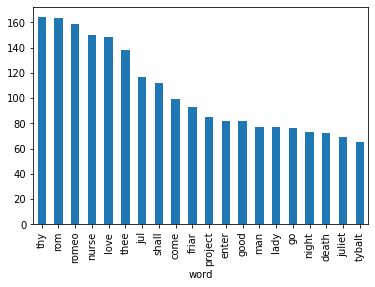

```python
#visualizazing the DataFrame

axes = df.plot.bar(x='word',y='count', legend=False)
```

#### b. Menggunakan Word Clouds

```python
#!pip install wordcloud

#!pip install wordcloud
```

```python
#Loading the text

from pathlib import Path

text = Path('RomeoAndJuliet.txt').read_text()
```

```python
#configuring the WordCloud object

from wordcloud import WordCloud

wordcloud = WordCloud(colormap='prism', background_color='white')
```

```python
#generating the Word Cloud

wordcloud = wordcloud.generate(text)
```

```python
#saving the Word Cloud as an image file

wordcloud = wordcloud.to_file('RomeoAndJulietWordCloud.png')
```

## ---Challenge---

#### 1. Ambil kata-kata dari satu dokumen sampel (Shakespeare-hamlet.txt) di corpus Gutenberg dan tampilkan.

```python
#Various techiques for detecting similarity between documents rely on word frequencies.

#use Path class form the Python Standard Library's pathlib module

from pathlib import Path
from textblob import TextBlob

#Load the e-book RomeoAndJuliet.txt(untuk memudahkan, letakan file di path yang sama dengan tempat menyimpan ipynb ini)
blob1 = TextBlob(Path('shakespeare.txt').read_text())
print(blob1)
```

[output not shown]

[output cut: 5012 more lines]

[output not shown]

```python
print(blob1[:500])
```

```
ï»¿The Project Gutenberg eBook of Hamlet, by William Shakespeare

This eBook is for the use of anyone anywhere in the United States and
most other parts of the world at no cost and with almost no restrictions
whatsoever. You may copy it, give it away or re-use it under the terms
of the Project Gutenberg License included with this eBook or online at
www.gutenberg.org. If you are not located in the United States, you
will have to check the laws of the country where you are located before
using thi
```

#### 3. Lakukan proses Tokenization,Stemming,Lemmatization dan POS Tags pada paragraf tersebut.

#### a.Tokenizing

```python
#sentence property to get a list of Sentence objects

blob1[:500].sentences
```

```
[Sentence("ï»¿The Project Gutenberg eBook of Hamlet, by William Shakespeare

 This eBook is for the use of anyone anywhere in the United States and
 most other parts of the world at no cost and with almost no restrictions
 whatsoever."),
 Sentence("You may copy it, give it away or re-use it under the terms
 of the Project Gutenberg License included with this eBook or online at
 www.gutenberg.org."),
 Sentence("If you are not located in the United States, you
 will have to check the laws of the country where you are located before
 using thi")]
```

```python
#words property returns a WordList object containing a list of Word objects

blob1[:500].words
```

```
WordList(['ï', '»', '¿The', 'Project', 'Gutenberg', 'eBook', 'of', 'Hamlet', 'by', 'William', 'Shakespeare', 'This', 'eBook', 'is', 'for', 'the', 'use', 'of', 'anyone', 'anywhere', 'in', 'the', 'United', 'States', 'and', 'most', 'other', 'parts', 'of', 'the', 'world', 'at', 'no', 'cost', 'and', 'wit…
```

#### b. POS Tagging

```python
#tags property returns a list of tuples, each containing a word and a string representing its part-of-speech tag

blob1[:500].tags
```

```
[('ï', 'JJ'),
 ('»', 'NNP'),
 ('¿The', 'NNP'),
 ('Project', 'NNP'),
 ('Gutenberg', 'NNP'),
 ('eBook', 'NN'),
 ('of', 'IN'),
 ('Hamlet', 'NNP'),
 ('by', 'IN'),
 ('William', 'NNP'),
 ('Shakespeare', 'NNP'),
 ('This', 'DT'),
 ('eBook', 'NN'),
 ('is', 'VBZ'),
 ('for', 'IN'),
 ('the', 'DT'),
 ('use', 'NN'),
 ('of', 'IN'),
 ('anyone', 'NN'),
 ('anywhere', 'RB'),
 ('in', 'IN'),
 ('the', 'DT'),
 ('United', 'NNP'),
 ('States', 'NNPS'),
 ('and', 'CC'),
 ('most', 'JJS'),
 ('other', 'JJ'),
 ('parts', 'NNS'),
 ('of', 'IN'),
 ('the', 'DT'),
 ('world', 'NN'),
 ('at', 'IN'),
 ('no', 'DT'),
 ('cost', 'NN'),
 ('and', 'CC'),
 ('with', 'IN'),
 ('almost', 'RB'),
 ('no', 'DT'),
 ('restrictions', 'NNS'),
 ('whatsoever', 'RB'),
```

[output cut: 37 more lines]

```
 ('have', 'VB'),
 ('to', 'TO'),
 ('check', 'VB'),
 ('the', 'DT'),
 ('laws', 'NNS'),
 ('of', 'IN'),
 ('the', 'DT'),
 ('country', 'NN'),
 ('where', 'WRB'),
 ('you', 'PRP'),
 ('are', 'VBP'),
 ('located', 'VBN'),
 ('before', 'IN'),
 ('using', 'VBG'),
 ('thi', 'NN')]
```

```python
#noun_phrases property returns a word objects - one for each noun phrase in the text

blob1[:500].noun_phrases
```

```
WordList(['ï » ¿the', 'project gutenberg', 'hamlet', 'william shakespeare', 'restrictions whatsoever', 'project gutenberg license'])
```

#### Melakukan analisis sentimen (sentiment analysis) menggunakan Sentiment Analyzer dari TextBlob(Challenge).

```python
#getting the sentiment of a TextBlob

blob1[:500].sentiment
```

```
Sentiment(polarity=0.1875, subjectivity=0.4375)
```

```python
#getting the polarity and subjectvity from the Sentiment Object

%precision 3
```

```
'%.3f'
```

```python
blob1[:500].sentiment.polarity
```

```
0.188
```

```python
blob1[:500].sentiment.subjectivity
```

```
0.438
```

```python
#getting the sentiment of a sentence
#get the sentiment at the individual sentence level

for sentence in blob1[:500].sentences:
    print(sentence.sentiment)
```

```
Sentiment(polarity=0.1875, subjectivity=0.4375)
Sentiment(polarity=0.0, subjectivity=0.0)
Sentiment(polarity=0.0, subjectivity=0.0)
```

#### c. Lemmatization and Stemming

```python
blob1[:500].words.lemmatize()
```

```
WordList(['ï', '»', '¿The', 'Project', 'Gutenberg', 'eBook', 'of', 'Hamlet', 'by', 'William', 'Shakespeare', 'This', 'eBook', 'is', 'for', 'the', 'use', 'of', 'anyone', 'anywhere', 'in', 'the', 'United', 'States', 'and', 'most', 'other', 'part', 'of', 'the', 'world', 'at', 'no', 'cost', 'and', 'with…
```

```python
blob1[:500].words.stem()
```

```
WordList(['ï', '»', '¿the', 'project', 'gutenberg', 'ebook', 'of', 'hamlet', 'by', 'william', 'shakespear', 'thi', 'ebook', 'is', 'for', 'the', 'use', 'of', 'anyon', 'anywher', 'in', 'the', 'unit', 'state', 'and', 'most', 'other', 'part', 'of', 'the', 'world', 'at', 'no', 'cost', 'and', 'with', 'alm…
```

```python
!jupyter nbconvert --to html "./00000054804_Christopher Darren_Week8.ipynb" --output-dir="./"
```

```
[NbConvertApp] Converting notebook ./00000054804_Christopher Darren_Week8.ipynb to html
[NbConvertApp] Writing 927481 bytes to 00000054804_Christopher Darren_Week8.html
```